# Red Wine Quality - Bing Yu

# Univariate Analysis

### What is the structure of your dataset?

There are 1599 samples of red wine with 12 variables. 11 of the varables are based on physicochemical tests and one output variable based on sensory data is quality.

The output feature is the wine quality. Most of the red wine quality is at 5,6, there are limited number of samples at lower quality (score of 3 or 4) and samples for high quality(7,8).

The 11 input features are all numbers spread at different range.

### What is/are the main feature(s) of interest in your dataset?

The main feature I am looking is the quality of red wine, I am trying to understand how the other 11 features would or would not impact the quality of the red wine.

### What other features in the dataset do you think will help support your investigation into your feature(s) of interest?

It is hard to tell which features will impact the quality of wine by looking into the distributions for now. I would include all of the 11 input features in my analysis for next steps, to supprot my investigation.

### Did you create any new variables from existing variables in the dataset?

I created a new variable of quality rating, by converting quality from int to factor. This will help to classify the wine.

### Of the features you investigated, were there any unusual distributions? Did you perform any operations on the data to tidy, adjust, or change the form of the data? If so, why did you do this?

The distribution of residula suger,chlorides,and sulphates has long tail, so I converted the x scale to log 10 to better analyze the distribution.

It is interesting to see that citric acid has a lot of samples with the value 0, which is unique comparing to other features. It is hard to tell wether it is data quality issue or it is a reflection of the truth. I will keep the data as it is.

Most of the samples’ total sulfur dioxide value is below 150, the larger the value is, the smaller the number is. When analyzing total sulfur dioxide, I limited the scale to less than 150

I have noticed that most of the alcohol value is between 9~14, I could limited the scalce between 9-14 to focus on the analysis.

Quality has lots of sample with the value of 5 and 6, and less examples when the quality is poor or excellent. It would bring difficulty for trying to distinguish the wine to different quality levels in further analysis.

# Bivariate Plots Section

## Scatterplot matrix and coorelation for all variables

Using scatterplot matrix to understand the correlation between all of the variables

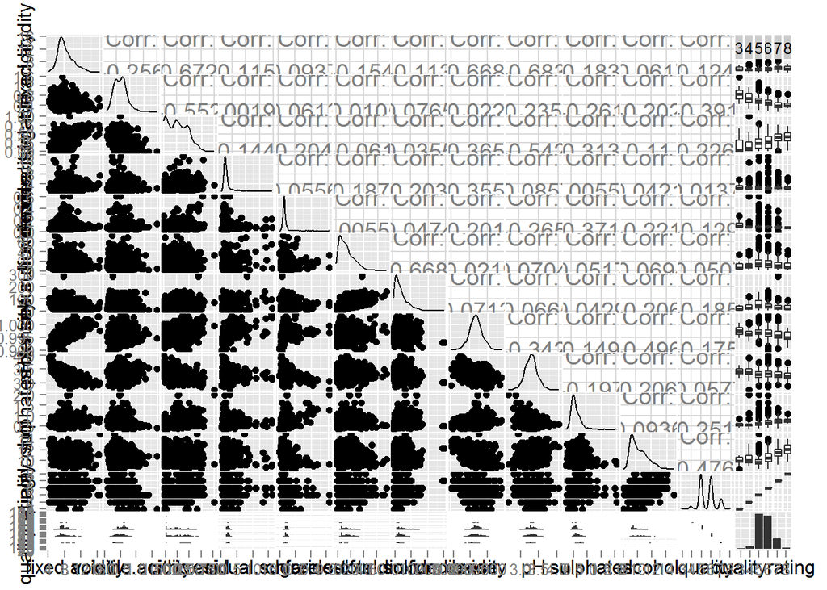

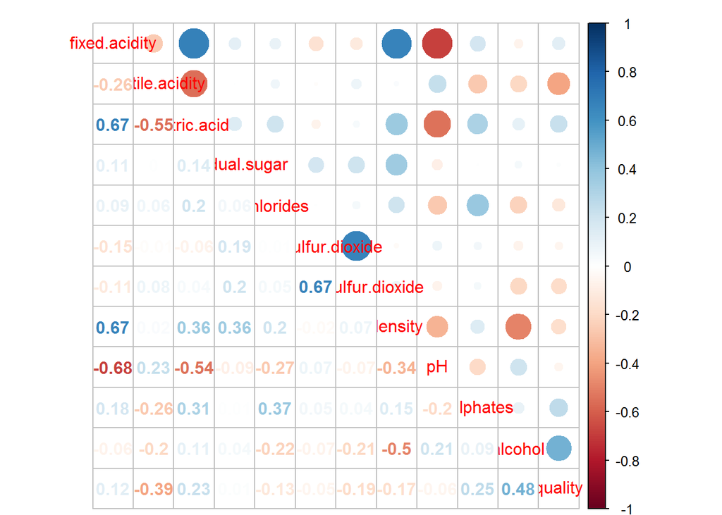

The wine quality does not have strong correlation with all do the variables, as all of the coeficients are less than 0.5. I want to firstly look closer of the scatter plot & box plot to understand the relationship between quality and other 11 variables. And then I will look into the relationship among the 11 input features, which have relatively larger correlation coeficients

## Bivariate plots for quality with input features

Explore the relationship of quality with other 11 input features.

### Quality Vs Fixed acidity

Explore the relationship between quality and fixed acidity through scatter plot & box plot, adding the line of mean value (blue line) and the line of smoothline (red line) by using locally weighted regression method to show the trend.

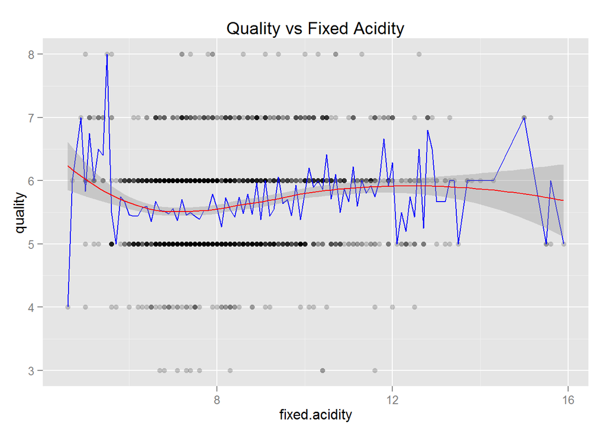

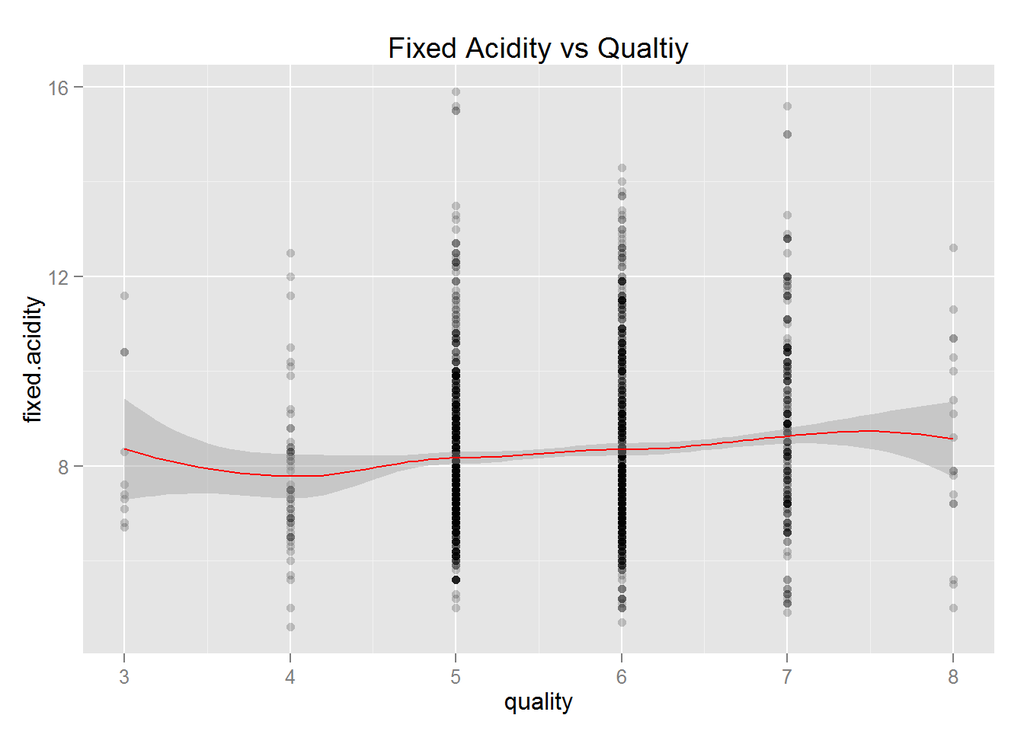

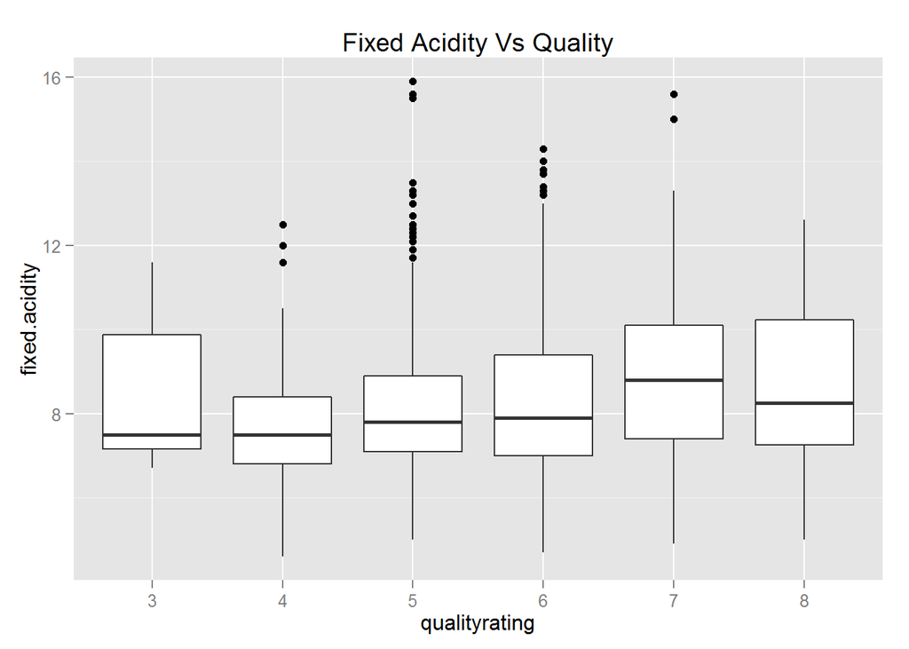

```
##
##  Pearson's product-moment correlation
##
## data:  fixed.acidity and quality
## t = 4.996, df = 1597, p-value = 6.496e-07
## alternative hypothesis: true correlation is not equal to 0
## 95 percent confidence interval:
##  0.07548957 0.17202667
## sample estimates:
##       cor
## 0.1240516
```

The scatterplot shows the distribution of quality vary with fixed acidity.When fixed acidity is less than 8, the quality decreases with the fixed acidity.But when the fixed acidity greater than 8, the quality increases with fixed acidity.

The mean quality value line has lots of variation and the scatter plot of fixed acidity varies with quality does not show clear trend, I will remove them from plots for further analysis.

Using the boxplot of the factor variable - quality factor, could better show the distribution of fixed acidity at different wine quality level. It shows positive correlation between these two variables, when the quality rating is higher, the wine tends to have larger value of fixed acidity.

The correlation coefficient between fixed acidity and wine quality is 0.12, there is no strong correlation between these two variables.

### Quality vs Volatile acidity

Explore the relationship between quality and volatile acidity.

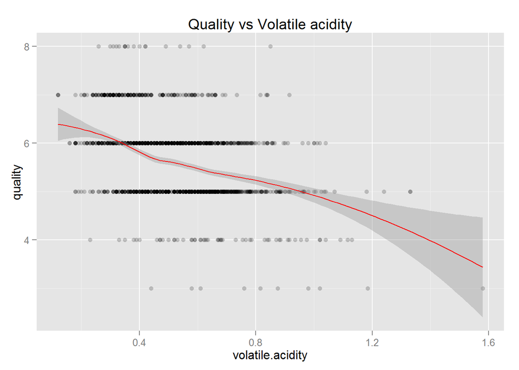

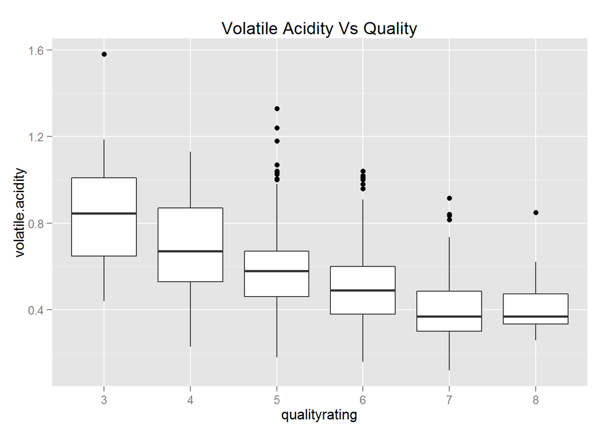

```
##
##  Pearson's product-moment correlation
##
## data:  volatile.acidity and quality
## t = -16.9542, df = 1597, p-value < 2.2e-16
## alternative hypothesis: true correlation is not equal to 0
## 95 percent confidence interval:
##  -0.4313210 -0.3482032
## sample estimates:
##        cor
## -0.3905578
```

```
## redwine$qualityrating: 3
##    Min. 1st Qu.  Median    Mean 3rd Qu.    Max.
##  0.4400  0.6475  0.8450  0.8845  1.0100  1.5800
## --------------------------------------------------------
## redwine$qualityrating: 4
##    Min. 1st Qu.  Median    Mean 3rd Qu.    Max.
##   0.230   0.530   0.670   0.694   0.870   1.130
## --------------------------------------------------------
## redwine$qualityrating: 5
##    Min. 1st Qu.  Median    Mean 3rd Qu.    Max.
##   0.180   0.460   0.580   0.577   0.670   1.330
## --------------------------------------------------------
## redwine$qualityrating: 6
##    Min. 1st Qu.  Median    Mean 3rd Qu.    Max.
##  0.1600  0.3800  0.4900  0.4975  0.6000  1.0400
## --------------------------------------------------------
## redwine$qualityrating: 7
##    Min. 1st Qu.  Median    Mean 3rd Qu.    Max.
##  0.1200  0.3000  0.3700  0.4039  0.4850  0.9150
## --------------------------------------------------------
## redwine$qualityrating: 8
##    Min. 1st Qu.  Median    Mean 3rd Qu.    Max.
##  0.2600  0.3350  0.3700  0.4233  0.4725  0.8500
```

The smooth line of the scatter plot shows that volatile acidity and quality has negative association, The higher the volatile acidity is, the lower the mean quality value. Same trend could be found through the boxplot as well, as the volatile acidity tends to have higer value when the quality rating is lower. And the correlation coeficient of those two variables is -0.39, relatively strong negative association.

### Quality vs Citric Acid

Explore the relationship between quality and citric acid.

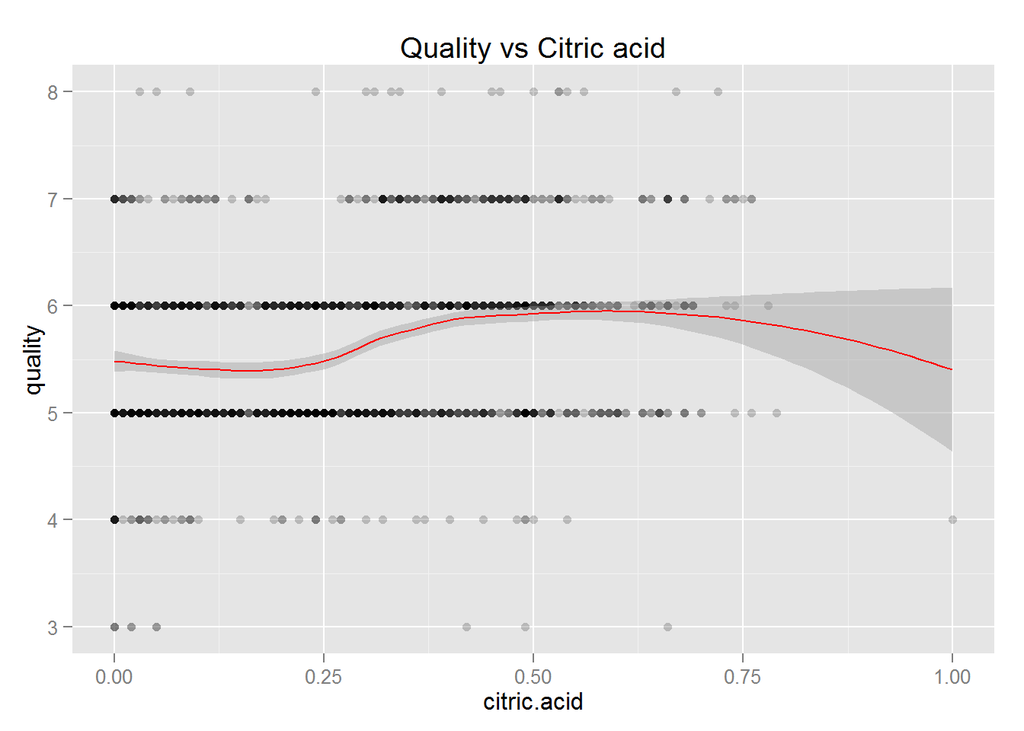

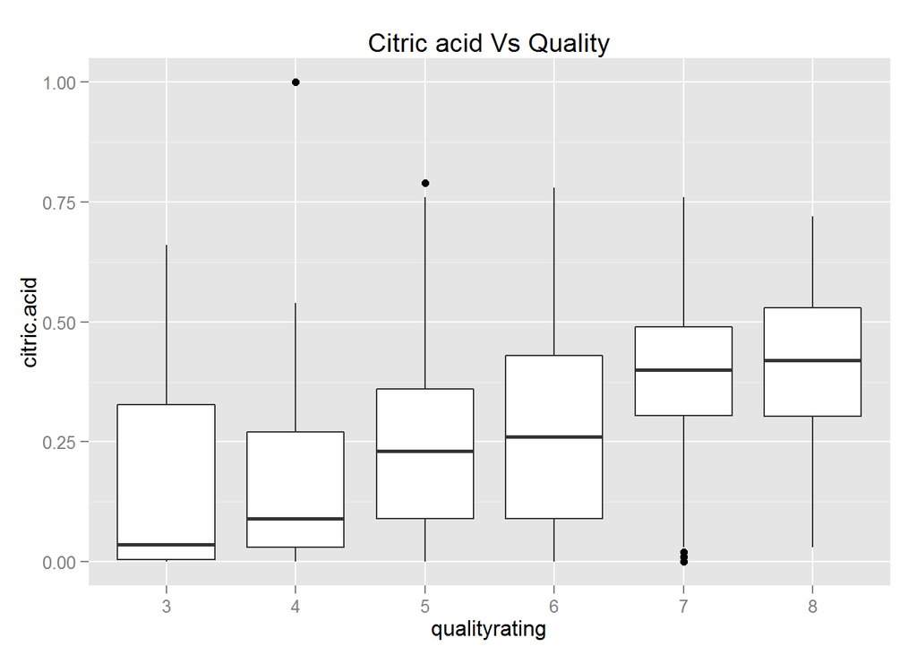

```
##
##  Pearson's product-moment correlation
##
## data:  citric.acid and quality
## t = 9.2875, df = 1597, p-value < 2.2e-16
## alternative hypothesis: true correlation is not equal to 0
## 95 percent confidence interval:
##  0.1793415 0.2723711
## sample estimates:
##       cor
## 0.2263725
```

The scatter plot shows a positive association between quality and citric acid. It is more clearer through the box plot. When the wine quality rating is higher, the citric acid has larger median value. But there is not much difference of the highest & lowest value of the ciric acid at different quality level. The correlation coefficient is only 0.226.

### Quality vs Residual sugar

Explore relationship between quality and residual sugar.

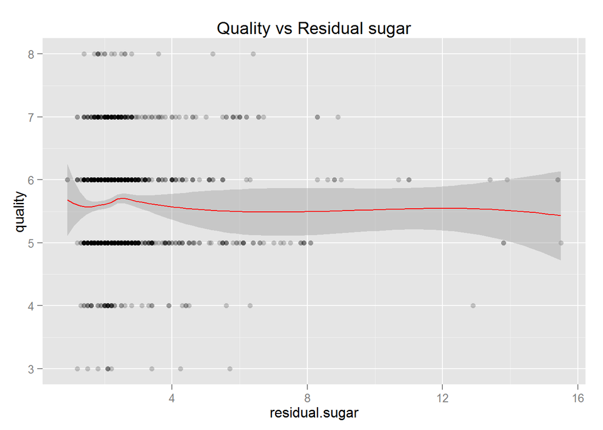

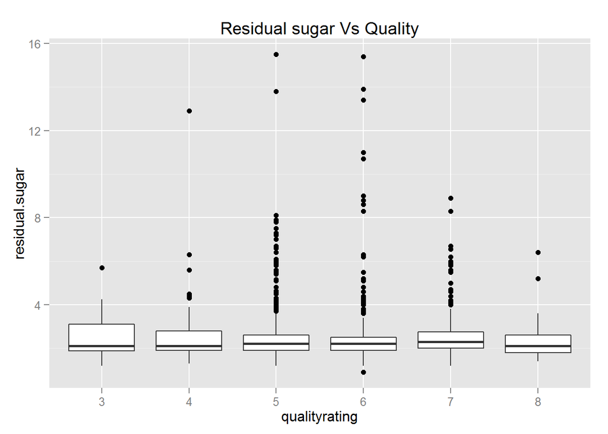

```
##
##  Pearson's product-moment correlation
##
## data:  residual.sugar and quality
## t = 0.5488, df = 1597, p-value = 0.5832
## alternative hypothesis: true correlation is not equal to 0
## 95 percent confidence interval:
##  -0.03531327  0.06271056
## sample estimates:
##        cor
## 0.01373164
```

There is no clear trend from the scatter plot, and residual suger has closer median value at different quality level. And there are lots of outliers at quality 5 to 7. The correlation coefficient of 0.014 shows no strong correlation between those two variables.

### Quality vs Chlorides

Explore the relationship between quality and chlorides, coverting the chlorides scale to log10 since it has a long tail distribution.

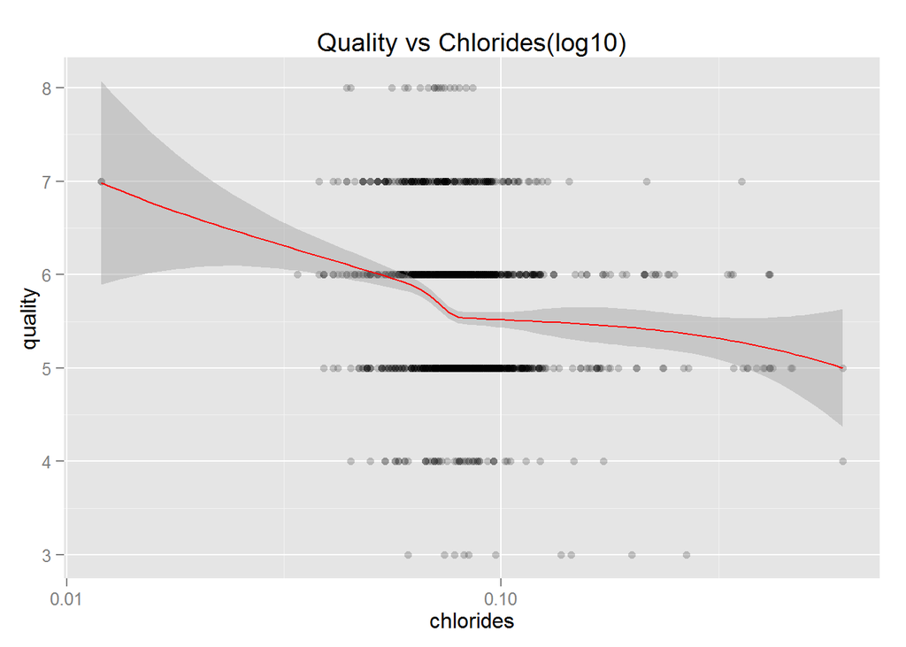

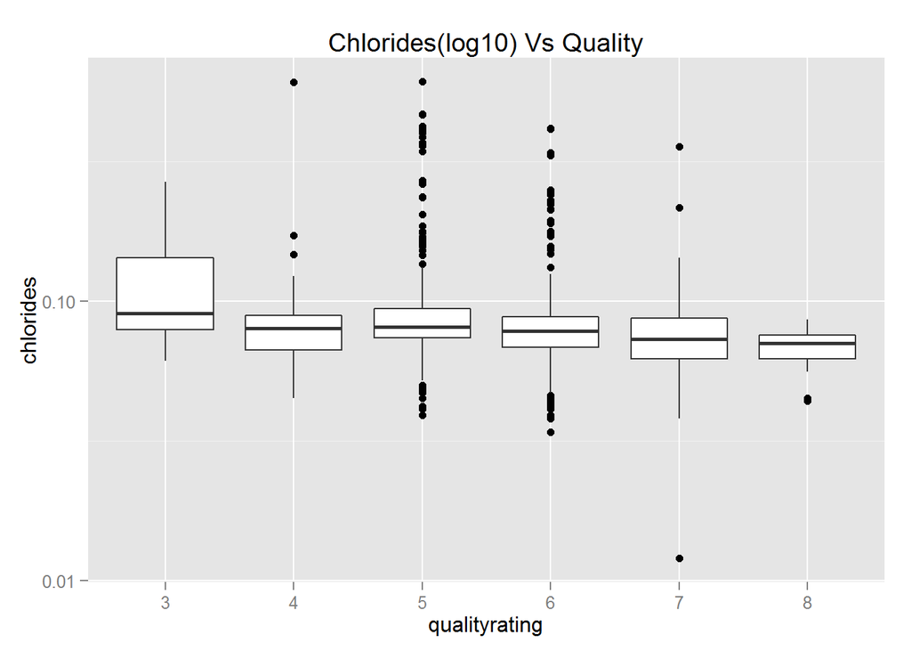

```
##
##  Pearson's product-moment correlation
##
## data:  chlorides and quality
## t = -5.1948, df = 1597, p-value = 2.313e-07
## alternative hypothesis: true correlation is not equal to 0
## 95 percent confidence interval:
##  -0.17681041 -0.08039344
## sample estimates:
##        cor
## -0.1289066
```

The scatter plot shows quality has negative association with chlorides, and when the quality rating is lower, chlorides has higher median value. But the median value of wine quality level 5 is slightly higher than level 4. There are lots of outliers at level 5 & 6, that’s where most of the samples fall into. The correlation of this two variables is not strong.

### Quality vs Free sulfur dioxide

Explore relationship between quality and free sulfur dioxide.

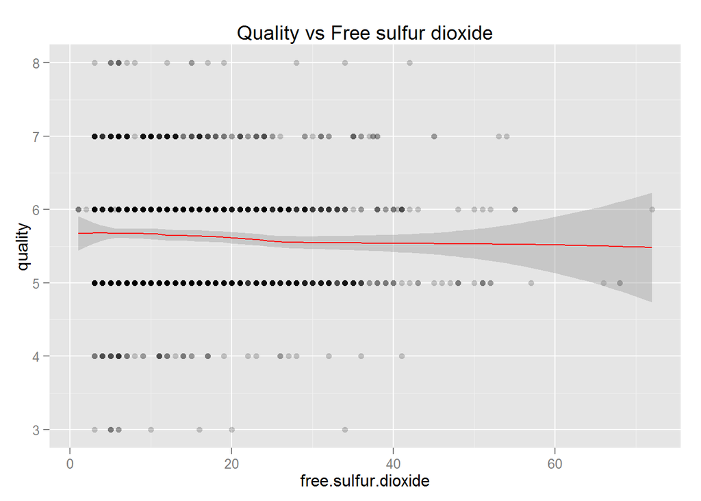

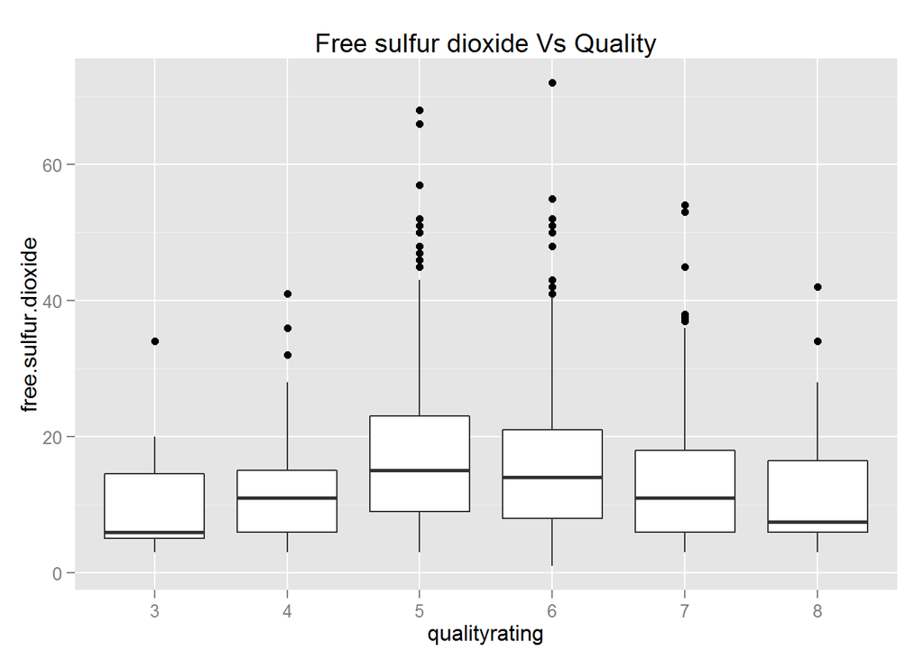

```
##
##  Pearson's product-moment correlation
##
## data:  free.sulfur.dioxide and quality
## t = -2.0269, df = 1597, p-value = 0.04283
## alternative hypothesis: true correlation is not equal to 0
## 95 percent confidence interval:
##  -0.099430290 -0.001638987
## sample estimates:
##         cor
## -0.05065606
```

The smoothline of scatter plot is almost flat, no clear trend from the scatter plot. From the boxplot, when wine quality rating is less than 5, free sulfur dioxide has higher median value at higher quality level. But when the quality rating is greater than 5, it shows a reverse trend. And the coefficient of -0.05 shows a week negative association.